# Loan_Data_Slides slides

## *Home Loan Approval - Data Analysis and Classification Modelling*

#### WarriWes

#### 11 April 2018

## Analytics Vidhya - Problem Statement

#### About Company

> Dream Housing Finance company deals in all home loans. They have presence across all urban, semi urban and rural areas. Customer first apply for home loan after that company validates the customer eligibility for loan.

#### Problem

> Company wants to automate the loan eligibility process (real time) based on customer detail provided while filling online application form. These details are Gender, Marital Status, Education, Number of Dependents, Income, Loan Amount, Credit History and others. To automate this process, they have given a problem to identify the customers segments, those are eligible for loan amount so that they can specifically target these customers. Here they have provided a partial data set.

OK let's get started.

```python
# Import necessary modules
import pandas as pd
import numpy as np
import matplotlib.pyplot as plt
import seaborn as sns
sns.set(style='white')

# Read in the data
train = pd.read_csv('C:\\Users\\Wesley\\OneDrive\\DocuFrom5_14_16\\Documents\\2018\\Portfolio_Construction\\Loan_data_vidhya\\loan_data_train.csv')
test = pd.read_csv('C:\\Users\\Wesley\\OneDrive\\DocuFrom5_14_16\\Documents\\2018\\Portfolio_Construction\\Loan_data_vidhya\\loan_data_test.csv')
```

```python
train.head()
```

|  | Loan_ID | Gender | Married | Dependents | Education | Self_Employed | ApplicantIncome | CoapplicantIncome | LoanAmount | Loan_Amount_Term | Credit_History | Property_Area | Loan_Status |
| --- | --- | --- | --- | --- | --- | --- | --- | --- | --- | --- | --- | --- | --- |
| 0 | LP001002 | Male | No | 0 | Graduate | No | 5849 | 0.0 | NaN | 360.0 | 1.0 | Urban | Y |
| 1 | LP001003 | Male | Yes | 1 | Graduate | No | 4583 | 1508.0 | 128.0 | 360.0 | 1.0 | Rural | N |
| 2 | LP001005 | Male | Yes | 0 | Graduate | Yes | 3000 | 0.0 | 66.0 | 360.0 | 1.0 | Urban | Y |
| 3 | LP001006 | Male | Yes | 0 | Not Graduate | No | 2583 | 2358.0 | 120.0 | 360.0 | 1.0 | Urban | Y |
| 4 | LP001008 | Male | No | 0 | Graduate | No | 6000 | 0.0 | 141.0 | 360.0 | 1.0 | Urban | Y |

```python
test.head()
```

|  | Loan_ID | Gender | Married | Dependents | Education | Self_Employed | ApplicantIncome | CoapplicantIncome | LoanAmount | Loan_Amount_Term | Credit_History | Property_Area |
| --- | --- | --- | --- | --- | --- | --- | --- | --- | --- | --- | --- | --- |
| 0 | LP001015 | Male | Yes | 0 | Graduate | No | 5720 | 0 | 110.0 | 360.0 | 1.0 | Urban |
| 1 | LP001022 | Male | Yes | 1 | Graduate | No | 3076 | 1500 | 126.0 | 360.0 | 1.0 | Urban |
| 2 | LP001031 | Male | Yes | 2 | Graduate | No | 5000 | 1800 | 208.0 | 360.0 | 1.0 | Urban |
| 3 | LP001035 | Male | Yes | 2 | Graduate | No | 2340 | 2546 | 100.0 | 360.0 | NaN | Urban |
| 4 | LP001051 | Male | No | 0 | Not Graduate | No | 3276 | 0 | 78.0 | 360.0 | 1.0 | Urban |

Notes:

- Gender, Married, Education, Self_Employed, Loan_Status columns look like character values, while Credit_History seems to be displayed in 1,0 dummy format
- Loan_Amount_Term recorded as # of days
- looks like we'll be dealing with some NaN values

```python
# For the sake of data exploration, analysis, and tidying, we'll merge the train and test sets for now
train['source'] = 'train'
test['source'] = 'test'
df = pd.concat([train, test], ignore_index=True)
print(train.shape, test.shape, df.shape)
```

```
(614, 14) (367, 13) (981, 14)
```

Now we'll take a peek inside the data we're working with.

```python
# Summary stats for numerics
df.describe()
```

|  | ApplicantIncome | CoapplicantIncome | Credit_History | LoanAmount | Loan_Amount_Term |
| --- | --- | --- | --- | --- | --- |
| count | 981.000000 | 981.000000 | 902.000000 | 954.000000 | 961.000000 |
| mean | 5179.795107 | 1601.916330 | 0.835920 | 142.511530 | 342.201873 |
| std | 5695.104533 | 2718.772806 | 0.370553 | 77.421743 | 65.100602 |
| min | 0.000000 | 0.000000 | 0.000000 | 9.000000 | 6.000000 |
| 25% | 2875.000000 | 0.000000 | 1.000000 | 100.000000 | 360.000000 |
| 50% | 3800.000000 | 1110.000000 | 1.000000 | 126.000000 | 360.000000 |
| 75% | 5516.000000 | 2365.000000 | 1.000000 | 162.000000 | 360.000000 |
| max | 81000.000000 | 41667.000000 | 1.000000 | 700.000000 | 480.000000 |

```python
# Missing values in all columns
df.isnull().sum()
```

```
ApplicantIncome        0
CoapplicantIncome      0
Credit_History        79
Dependents            25
Education              0
Gender                24
LoanAmount            27
Loan_Amount_Term      20
Loan_ID                0
Loan_Status          367
Married                3
Property_Area          0
Self_Employed         55
source                 0
dtype: int64
```

Note the decent number of null values.  
In Loan_Status, of course, the null values are from our test set.

```python
# Print means, medians, and standard deviation of each column to check for spread and skewness
print(df.mean(axis=0))
print(df.median(axis=0))
print(df.std(axis=0))
# Difference between mean and median in each column
df.mean(axis=0) - df.median(axis=0)
```

```
ApplicantIncome      5179.795107
CoapplicantIncome    1601.916330
Credit_History          0.835920
LoanAmount            142.511530
Loan_Amount_Term      342.201873
dtype: float64
ApplicantIncome      3800.0
CoapplicantIncome    1110.0
Credit_History          1.0
LoanAmount            126.0
Loan_Amount_Term      360.0
dtype: float64
ApplicantIncome      5695.104533
CoapplicantIncome    2718.772806
Credit_History          0.370553
LoanAmount             77.421743
Loan_Amount_Term       65.100602
dtype: float64
```

```
ApplicantIncome      1379.795107
CoapplicantIncome     491.916330
Credit_History         -0.164080
LoanAmount             16.511530
Loan_Amount_Term      -17.798127
dtype: float64
```

```python
# List column types
df.dtypes
```

```
ApplicantIncome        int64
CoapplicantIncome    float64
Credit_History       float64
Dependents            object
Education             object
Gender                object
LoanAmount           float64
Loan_Amount_Term     float64
Loan_ID               object
Loan_Status           object
Married               object
Property_Area         object
Self_Employed         object
source                object
dtype: object
```

```python
# Print frequencies of values for all categorical variables
categ_cols = ['Gender', 'Married', 'Dependents', 'Education', 'Self_Employed', 'Loan_Amount_Term', 'Credit_History', 'Property_Area', 'Loan_Status']
for col in categ_cols:
    print(df[col].value_counts(), '\n')
```

```
Male      775
Female    182
Name: Gender, dtype: int64

Yes    631
No     347
Name: Married, dtype: int64

0     545
1     160
2     160
3+     91
Name: Dependents, dtype: int64

Graduate        763
Not Graduate    218
Name: Education, dtype: int64

No     807
Yes    119
Name: Self_Employed, dtype: int64

360.0    823
180.0     66
480.0     23
300.0     20
240.0      8
84.0       7
120.0      4
36.0       3
60.0       3
12.0       2
350.0      1
6.0        1
Name: Loan_Amount_Term, dtype: int64

1.0    754
0.0    148
Name: Credit_History, dtype: int64

Semiurban    349
Urban        342
Rural        290
Name: Property_Area, dtype: int64

Y    422
N    192
Name: Loan_Status, dtype: int64
```

## Looking at numeric variable distributions

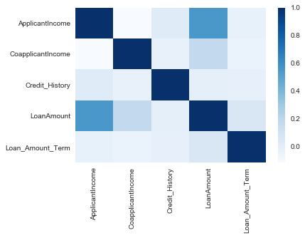

```python
# Quick look at correlations:
corr = df.corr()
sns.heatmap(corr, cmap='Blues')
plt.show()
```

### Applicant Income and Loan Amount

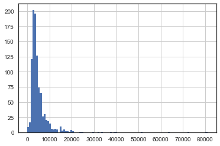

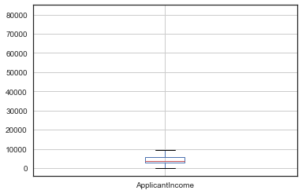

```python
df['ApplicantIncome'].hist(bins=100)
plt.show()
df.boxplot(column = 'ApplicantIncome')
plt.show()
```

Note the extreme right skew, with just a few values between about 20,000 and 81,000

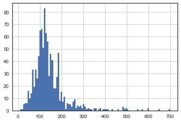

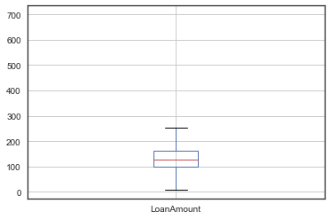

```python
df['LoanAmount'].hist(bins=100)
plt.show()
df.boxplot(column = 'LoanAmount')
plt.show()
```

We also have a nice right skew here, though not quite as extreme as in the ApplicantIncome distribution

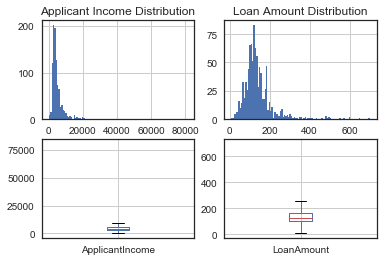

```python
plt.subplot(2, 2, 1)
df['ApplicantIncome'].hist(bins=100)
plt.title('Applicant Income Distribution')
plt.subplot(2, 2, 3)
df.boxplot(column='ApplicantIncome')
plt.subplot(2, 2, 2)
df['LoanAmount'].hist(bins=100)
plt.title('Loan Amount Distribution')
plt.subplot(2, 2, 4)
df.boxplot(column='LoanAmount')
plt.show()
```

##### Looking at Applicant Income distribution dependent on education,

##### marital status, number of dependents, property area, and gender

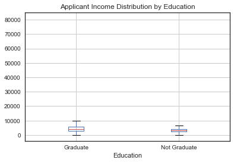

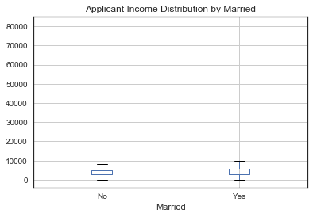

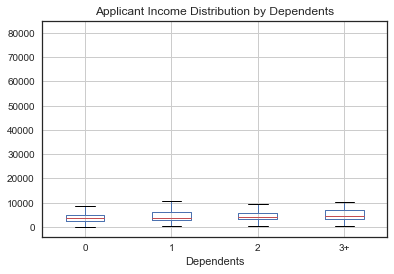

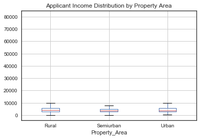

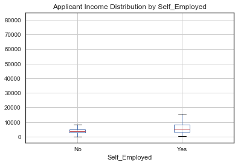

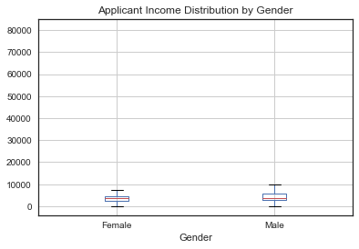

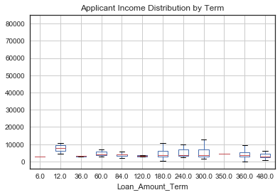

```python
df.boxplot(column='ApplicantIncome', by='Education')
plt.suptitle('')
plt.title('Applicant Income Distribution by Education')
plt.show()

df.boxplot(column='ApplicantIncome', by='Married')
plt.suptitle('')
plt.title('Applicant Income Distribution by Married')
plt.show()

df.boxplot(column='ApplicantIncome', by='Dependents')
plt.suptitle('')
plt.title('Applicant Income Distribution by Dependents')
plt.show()

df.boxplot(column='ApplicantIncome', by='Property_Area')
plt.suptitle('')
plt.title('Applicant Income Distribution by Property Area')
plt.show()

df.boxplot(column='ApplicantIncome', by='Self_Employed')
plt.suptitle('')
plt.title('Applicant Income Distribution by Self_Employed')
plt.show()

df.boxplot(column='ApplicantIncome', by='Gender')
plt.suptitle('')
plt.title('Applicant Income Distribution by Gender')
plt.show()

df.boxplot(column='ApplicantIncome', by='Loan_Amount_Term')
plt.suptitle('')
plt.title('Applicant Income Distribution by Term')
plt.show()
```

Comparing **income distribution** grouped by a few of the variables, we may consider that perhaps our extreme right skew merely reflects the income gap in society, in addition to chance with regard to the selected sample. It makes sense that college graduates would be more likely to make more, and education appears to be the greatest factor (of the variables we have to work with) in determining whether or not an applicant will have a high, outlier-grade income.

**Marital status** is also worth looking at. Married applicants may be more likely to have a relatively stable financial situation (including credit history, etc.), considering that stability is often a prerequisite for those who decide to settle down and get hitched.

**Self-employed** applicants also boast a generally higher IQR, although there aren't as many very high incomes, and let's remember that there are over 6 times as many non-self-employed applicants in this sample.

### Applicant and Coapplicant Income

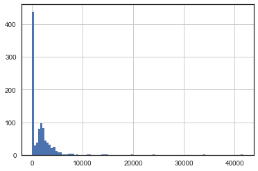

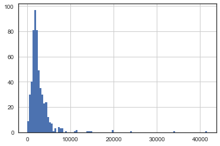

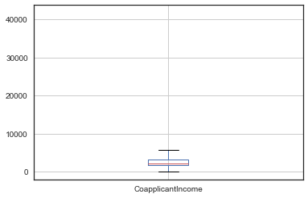

```python
df['CoapplicantIncome'].hist(bins=100)
plt.show()

# So yeah let's briefly change 0 values to null in order to get a better view of the distribution
df['CoapplicantIncome'] = df['CoapplicantIncome'].replace(0.0, np.nan)
df['CoapplicantIncome'].hist(bins=100)
plt.show()
df.boxplot(column = 'CoapplicantIncome')
plt.show()
```

Also highly right skewed. Likely for the same general reasons as ApplicantIncome

```python
# Change our null values back to 0s
df['CoapplicantIncome'] = df['CoapplicantIncome'].replace(np.nan, 0.0)
# Let's check to see how the presence/absence of coapplicant income relates to marital status:
co_inc_tf = df.CoapplicantIncome > 0
print(df.pivot_table(index='Married', columns=co_inc_tf, values='Loan_ID', aggfunc='count'))
# Proportions
df.pivot_table(index='Married', columns=co_inc_tf, values='Loan_ID', aggfunc='count').apply(lambda x: x / df.Loan_ID.count())
```

```
CoapplicantIncome  False  True
Married
No                   224    123
Yes                  203    428
```

| CoapplicantIncome Married | False | True |
| --- | --- | --- |
| No | 0.228338 | 0.125382 |
| Yes | 0.206932 | 0.436290 |

So *yes*, married applicants are definitely more likely to have a coapplicant's income included

Finally a quick look at **Loan_Amount** relationships. I expect to see  
results similar to ApplicantIncome, as these variables were highly correlated,  
and further correlated to similar other variables

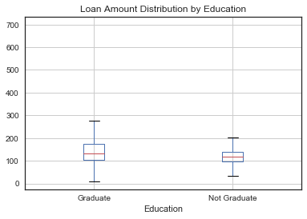

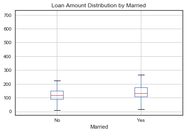

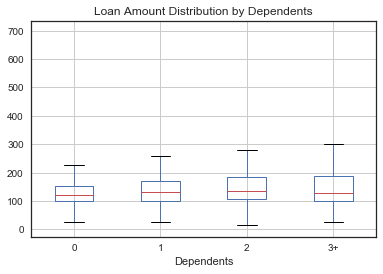

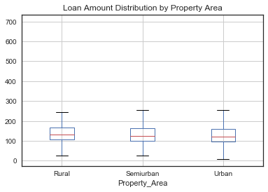

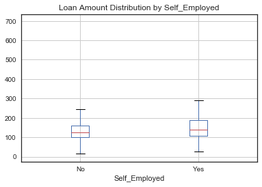

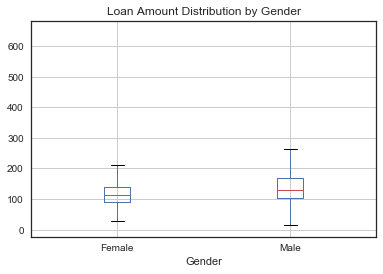

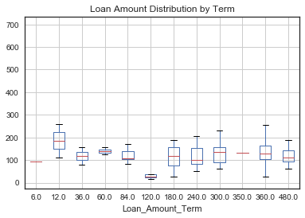

```python
df.boxplot(column='LoanAmount', by='Education')
plt.suptitle('')
plt.title('Loan Amount Distribution by Education')
plt.show()

df.boxplot(column='LoanAmount', by='Married')
plt.suptitle('')
plt.title('Loan Amount Distribution by Married')
plt.show()

df.boxplot(column='LoanAmount', by='Dependents')
plt.suptitle('')
plt.title('Loan Amount Distribution by Dependents')
plt.show()

df.boxplot(column='LoanAmount', by='Property_Area')
plt.suptitle('')
plt.title('Loan Amount Distribution by Property Area')
plt.show()

df.boxplot(column='LoanAmount', by='Self_Employed')
plt.suptitle('')
plt.title('Loan Amount Distribution by Self_Employed')
plt.show()

df.boxplot(column='LoanAmount', by='Gender')
plt.suptitle('')
plt.title('Loan Amount Distribution by Gender')
plt.show()

df.boxplot(column='LoanAmount', by='Loan_Amount_Term')
plt.suptitle('')
plt.title('Loan Amount Distribution by Term')
plt.show()
```

## Categorical variable analysis

```python
# Let's go ahead and map any binary variables to 1s for 'Yes' values and 0s for 'No' values
# Gender:
df['Gender'] = df['Gender'].map({'Male':1.0, 'Female':0.0})
# Married:
df['Married'] = df['Married'].map({'Yes':1.0, 'No':0.0})
# Self_Employed:
df['Self_Employed'] = df['Self_Employed'].map({'Yes':1.0, 'No':0.0})
# Education:
df['Education'] = df['Education'].map({'Graduate':1.0, 'Not Graduate':0.0})
# Property_Area:
df['Property_Area'] = df['Property_Area'].map({'Urban':3.0, 'Semiurban':2.0, 'Rural':1.0})
# Loan_Status
df['Loan_Status'] = df['Loan_Status'].map({'Y':1.0, 'N':0.0})

df.head()
```

|  | ApplicantIncome | CoapplicantIncome | Credit_History | Dependents | Education | Gender | LoanAmount | Loan_Amount_Term | Loan_ID | Loan_Status | Married | Property_Area | Self_Employed | source |
| --- | --- | --- | --- | --- | --- | --- | --- | --- | --- | --- | --- | --- | --- | --- |
| 0 | 5849 | 0.0 | 1.0 | 0 | 1.0 | 1.0 | NaN | 360.0 | LP001002 | 1.0 | 0.0 | 3.0 | 0.0 | train |
| 1 | 4583 | 1508.0 | 1.0 | 1 | 1.0 | 1.0 | 128.0 | 360.0 | LP001003 | 0.0 | 1.0 | 1.0 | 0.0 | train |
| 2 | 3000 | 0.0 | 1.0 | 0 | 1.0 | 1.0 | 66.0 | 360.0 | LP001005 | 1.0 | 1.0 | 3.0 | 1.0 | train |
| 3 | 2583 | 2358.0 | 1.0 | 0 | 0.0 | 1.0 | 120.0 | 360.0 | LP001006 | 1.0 | 1.0 | 3.0 | 0.0 | train |
| 4 | 6000 | 0.0 | 1.0 | 0 | 1.0 | 1.0 | 141.0 | 360.0 | LP001008 | 1.0 | 0.0 | 3.0 | 0.0 | train |

```python
# Probability of getting a loan based on presence or absence of a credit history:
df.pivot_table(values='Loan_Status', index=['Credit_History'], aggfunc='mean')
```

| Credit_History | Loan_Status |
| --- | --- |
| 0.0 | 0.078652 |
| 1.0 | 0.795789 |

```python
# Similarly...
# Probability of getting a loan based on all categorical attributes:
try:
    for col in categ_cols:
        print(df.pivot_table(values='Loan_Status', index=[col], aggfunc='mean'), '\n')
except ValueError:
    pass
```

```
        Loan_Status
Gender
0.0        0.669643
1.0        0.693252

         Loan_Status
Married
0.0         0.629108
1.0         0.716080

            Loan_Status
Dependents
0              0.689855
1              0.647059
2              0.752475
3+             0.647059

           Loan_Status
Education
0.0           0.611940
1.0           0.708333

               Loan_Status
Self_Employed
0.0               0.686000
1.0               0.682927

                  Loan_Status
Loan_Amount_Term
6.0                       NaN
12.0                 1.000000
36.0                 0.000000
60.0                 1.000000
84.0                 0.750000
120.0                1.000000
180.0                0.659091
240.0                0.750000
300.0                0.615385
350.0                     NaN
360.0                0.701172
480.0                0.400000

                Loan_Status
Credit_History
0.0                0.078652
1.0                0.795789

               Loan_Status
Property_Area
1.0               0.614525
2.0               0.768240
3.0               0.658416
```

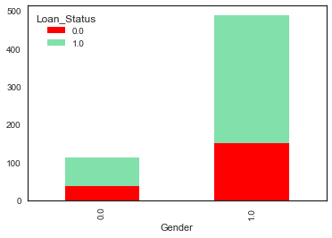

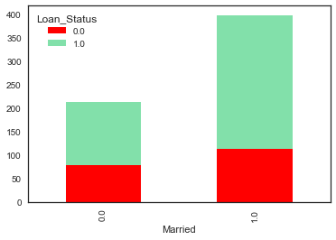

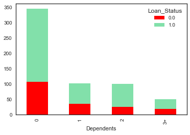

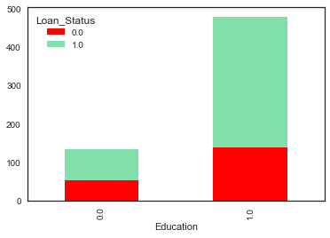

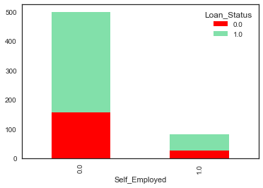

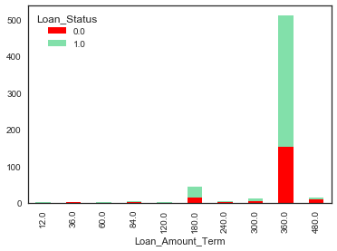

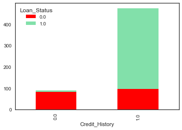

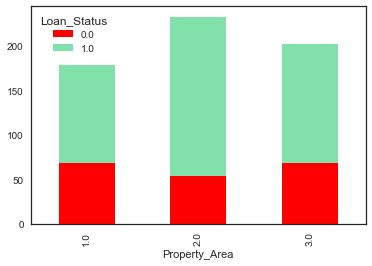

```python
# And probably of getting a loan approved based on all categories individually,
# visualized a little more nicely as stacked barplots
try:
    for col in categ_cols:
        pair = pd.crosstab(df[col], df['Loan_Status'])
        pair.plot.bar(stacked=True, color=['red', '#82E0AA'])
        plt.show()
except (ValueError, KeyError) as e:
    pass
```

Notes:

- Gender - many more male applicants
- Married - married applicants have a better record. Considering the gender gap,  
  let's remember to look at the relationship between Gender and Married.
- Dependents - Keep in mind that 3+ includes more than just applicants with 3 dependents.
- Education - As noted before, perhaps correlated with income, etc.
- Loan_Amount_Term - Overwhelmingly 1-year terms. We'll look at cleaning up the few  
  outliers below 3 months.
- Credit_History - Unsurprisingly linked with Loan_Status; may also be linked to Married, etc.
- Property_Area - SemiUrban looking good for probability of approval. I'm thinking married applicants  
  with decent income moving to the suburbs